# Tarea de Programación II

José Jorge Martínez de la Cruz

2026-04-30

# Construcción y simulación de cadenas de Markov en tiempo continuo

Una cadena de Markov en tiempo continuo (CTMC) puede construirse a partir de una cadena de Markov en tiempo discreto junto con tiempos de permanencia aleatorios.

## Construcción formal

Sea $(Y_n)_{n \ge 0}$ una cadena de Markov con probabilidades de transición $r(i,j)$ y sea $\lambda(i) > 0$ la tasa de salida del estado $i$.

**Paso 1: tiempos de permanencia.** Sea $(\tau_n)_{n \ge 0}$ una sucesión de variables aleatorias independientes tales que
$$\tau_n \sim Exp(1)$$
Definimos el tiempo que el proceso permanece en el estado $Y_n$ como
$$t_{n+1} = \frac{\tau_n}{\lambda(Y_n)}$$

**Paso 2: tiempos acumulados.** Definimos los tiempos de salto acumulados como
$$T_0 = 0$$
$$T_n = t_1 + t_2 + \dots + t_n$$

**Paso 3: definición del proceso continuo.** Definimos el proceso en tiempo continuo $(X(t))_{t \ge 0}$ mediante
$$X(t) = Y_n \quad
\text{si } T_n \le t < T_{n+1}$$
Es decir, el proceso permanece en el estado $Y_n$ durante el intervalo de tiempo de longitud $t_{n+1}$, y luego salta al siguiente estado $Y_{n+1}$.

## Versión equivalente

De manera equivalente, en el estado $i$ se puede generar directamente el tiempo de permanencia como
$$t \sim Exp(\lambda(i))$$
Ambas construcciones son equivalentes porque si $\tau \sim Exp(1)$, entonces
$$\frac{\tau}{\lambda} \sim Exp(\lambda)$$

## Algoritmo de simulación

Para simular una trayectoria de una CTMC:

1. Inicializar:
   $$T_0 = 0, \quad Y_0 = x_0$$
2. Para $n = 0, 1, 2, \dots$ repetir:
   1. Calcular la tasa total de salida del estado actual:
      $$\lambda(Y_n) = \sum_{j \neq Y_n} q(Y_n, j)$$
   2. Generar el tiempo de permanencia:
      - Versión 1: $\tau_n \sim Exp(1)$ y $t_{n+1} = \tau_n / \lambda(Y_n)$
      - Versión 2: $t_{n+1} \sim Exp(\lambda(Y_n))$
   3. Actualizar el tiempo:
      $$T_{n+1} = T_n +
      t_{n+1}$$
   4. Elegir el siguiente estado $Y_{n+1}$ con probabilidad:
      $$\mathbb{P}(Y_{n+1} = j \mid Y_n) = \frac{q(Y_n,
      j)}{\lambda(Y_n)}$$
3. Definir el proceso continuo mediante:
   $$X(t) = Y_n \quad \text{para } T_n \le t < T_{n+1}$$

```r
# Implementamos un algoritmo para cualquier modelo M/M/k
CMTC <- function(lambda, mu, k, T_max, x0 = 0) {
  # Lo hacemos como función para poder simular diferentes modelos de colas (M/M/1, M/M/5, M/M/inf)
  Y_n <- c(x0)
  t_n <- c(0) # Aquí los parametros de inicio
  T_n <- c(0)

  # repetiremos el siguiente bucle hasta alcanzar el tiempo máximo T_max
  while(tail(T_n, 1) < T_max) {
    estado_actual <- tail(Y_n, 1) # estado actual del proceso

    # aquí calculamos la tasa total de salida
    tasa_salida <- lambda + mu * min(estado_actual, k)

    # usaremos la versión 2 para generar el tiempo de permanencia directamente con la tasa
    t_next <- rexp(1, rate = tasa_salida) # tiempo de permanencia en el estado actual

    # actualizamos el tiempo
    T_next <- tail(T_n, 1) + t_next

    # eligiremos el siguiente estado con la probabilidad correspondiente
    prob_llegada <- lambda / tasa_salida
    if (runif(1) < prob_llegada) {
      next_Y <- estado_actual + 1
    } else {
      next_Y <- estado_actual - 1 # marcamos al condición de decisión
    }

    # guardamos los valores que necesitamos para graficar la trayectoria
    Y_n <- c(Y_n, next_Y)
    t_n <- c(t_n, t_next)
    T_n <- c(T_n, T_next)
  }

  ### para facilitar la graficación, creamos un data frame con los tiempos acumulados y los estados correspondientes
  datos_trayectoria <- data.frame(Tiempo_Tn = T_n, Estado_Yn = Y_n)
  return(datos_trayectoria) #Y de hecho, esto es lo que regresa la función
}
```

# Ejemplos: modelos de colas

Consideramos procesos con espacio de estados $\{0, 1, 2, \dots\}$ donde $X(t)$ representa el número de clientes en el sistema.

## Modelo M/M/1

- **Llegadas:** $n \to n+1$ con tasa $\lambda$
- **Salidas:** $n \to n-1$ con tasa $\mu$ ($n \ge 1$)
- **Tasa total:**
  $$\lambda(n) = \begin{cases} \lambda, & n=0 \\ \lambda+\mu, & n
  \ge 1 \end{cases}$$

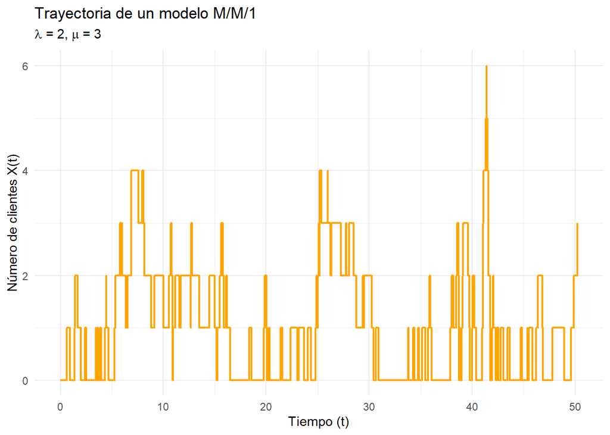

```r
set.seed(236) # reproducibilidad
data_sim_1 <- CMTC(lambda = 2, mu = 3, k = 1, T_max = 50)

ggplot(data_sim_1, aes(x = Tiempo_Tn, y = Estado_Yn)) +
  geom_step(direction = "hv", color = "orange", linewidth = 0.8) +
  theme_minimal() +
  labs(title = "Trayectoria de un modelo M/M/1",
       subtitle = expression(paste(lambda, " = 2, ", mu, " = 3")),
       x = "Tiempo (t)",
       y = "Número de clientes X(t)")
```

## Modelo M/M/5

- **Llegadas:** tasa $\lambda$
- **Salidas:** $n \to n-1$ con tasa $\mu \min(n, 5)$
- **Tasa total:**
  $$\lambda(n) = \lambda + \mu \min(n, 5)$$

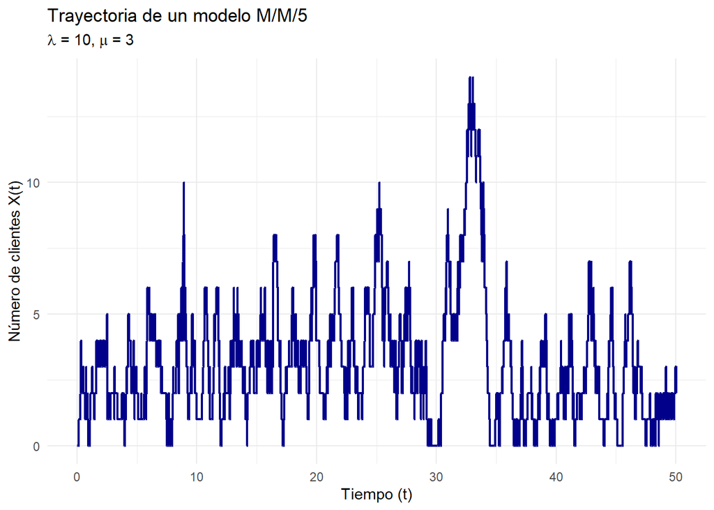

```r
set.seed(236)
data_sim_2 <- CMTC(lambda = 10, mu = 3, k = 5, T_max = 50)

ggplot(data_sim_2, aes(x = Tiempo_Tn, y = Estado_Yn)) +
  geom_step(direction = "hv", color = "darkblue", linewidth = 0.8) +
  theme_minimal() +
  labs(title = "Trayectoria de un modelo M/M/5",
       subtitle = expression(paste(lambda, " = 10, ", mu, " = 3")),
       x = "Tiempo (t)",
       y = "Número de clientes X(t)")
```

## Modelo M/M/$\infty$

- **Llegadas:** tasa $\lambda$
- **Salidas:** $n \to n-1$ con tasa $n\mu$
- **Tasa total:**
  $$\lambda(n) = \lambda + n\mu$$

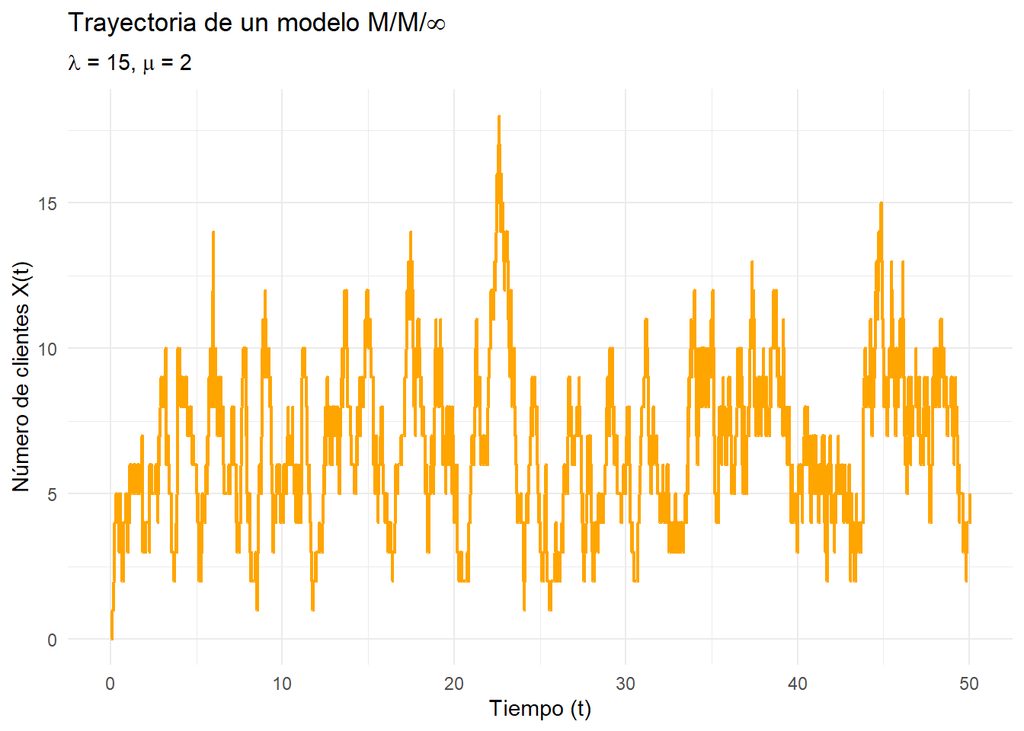

```r
set.seed(236)
# notemos que, al usar k = Inf, min(estado_actual, Inf) siempre es igual a estado_actual.
data_sim_3 <- CMTC(lambda = 15, mu = 2, k = Inf, T_max = 50)

ggplot(data_sim_3, aes(x = Tiempo_Tn, y = Estado_Yn)) +
  geom_step(direction = "hv", color = "orange", linewidth = 0.8) +
  theme_minimal() +
  labs(title = expression("Trayectoria de un modelo M/M/" * infinity),
       subtitle = expression(paste(lambda, " = 15, ", mu, " = 2")),
       x = "Tiempo (t)",
       y = "Número de clientes X(t)")
```

## Referencias

- Rincón, L. (2012). *Introducción a los procesos estocásticos*. Ciudad de México: Facultad de Ciencias, UNAM.
- Richard Durrett and R Durrett. Essentials of stochastic processes, vol ume 1. Springer, 1999.